# Relatório de publicação dos discentes e egressos do PPG Ecologia: Teoria, Aplicacão e Valores da UFBA - quadriênio 2017-2020

Prof. Dr. Bruno Vilela

2022-09-21

# Sobre

Nesse arquivo, monitoramos os dados de publicações de discentes e egressos no quadirênio e calculamos as métricas 2.1 e 2.2 da ficha de avaliação 2017-2020 para a área de biodiversidade.

# Preparacão

## Dados e scripts

Os dados e scripts disponibilizados aqui podem ser encontrados no seguinte link do github: https://github.com/BrunoVilela/relatorio_producao_discente-egresso_2017-2020/tree/main

Para replicar as análises clone o repositório do github e rode os códigos a seguir.

## Pacotes necessários

Instale e carregue os seguintes pacotes para replicar a análise. Note que o pacote `NUPEX` foi desenvolvido no Instituto de Biologia UFBA para acompanhamento anual da produção de discentes e docentes e está disponível para download no github, conforme instruções abaixo.

```r
library(tidyverse)
library(stringi)
library(magrittr)
library(scholar)
library(here)
# Para baixar o pacote NUPEX:
# devtools::install_github("BrunoVilela/NUPEX")
library(NUPEX)
```

## funções auxiliares

Para deixar esse relatório mais curto, funções auxiliares foram criadas em um outro script, carregue elas no R usando o código abaixo.

```r
source(here("Scripts", "funcoes_auxiliares.R"))
```

## Informacões do lattes

Primeiramente, extraimos os dados dos arquivos XML de cada discente e egresso.

```r
# lattes
ano_base = 2017:2020
path = here("Dados/lattes")

# Get the lattes
lattes_alunos <- get_lattes_folder(path, progress = FALSE)
```

## Qualis

O qualis de todas as revistas onde discentes e egressos publicaram seus artigos foram classificadas segundo as regras estabelecidas no documento de área. Ainda assim algumas revistas não puderam ser classificadas (símbolo `NA` nas análises).

```r
qualis <- read_csv(here("Dados/qualis", "qualis_revistas_publicadas.csv"))
qualis_estrato <- c("A1", "A2", "A3", "A4", "B1", "B2", "B3", "B4", "C")
```

### Combinar artigos com o qualis

A seguir combinamos os artigos com o qualis das revistas.

```r
papers <- lattes_alunos$papers %>%
  mutate(TITULO = gsub( "\\s*\\([^\\)]+\\)", "",`TITULO-DO-PERIODICO-OU-REVISTA`),
         TITULO = trimws(toupper(TITULO))) %>%
  mutate(ANO = `ANO-DO-ARTIGO`) %>%
  filter(ANO < 2021) %>%
  select(NOME, `TITULO-DO-ARTIGO`, TITULO, ISSN, ANO, DOI) %>%
  left_join(y = qualis, by = c("ISSN", "TITULO")) %>%
  distinct()
```

## Discentes e egressos do curso

Aqui carregamos os dados dos egressos do programa e padronizamos os nomes para as análises.

```r
egressos <- read.csv(here("Dados/alunos-egressos", "egressos.csv"))
egressos$Egresso <- toupper(stri_trans_general(str = egressos$Egresso,
                                               id = "Latin-ASCII"))
```

Aqui carregamos os dados dos discentes do programa e padronizamos os nomes para as análises.

```r
matriculados <- read.csv(here("Dados/alunos-egressos",
                              "matriculados_2017-2020.csv"),
                         encoding = "latin1")
matriculados$Matriculado.em <- gsub("\\..", "", matriculados$Matriculado.em)
matriculados$Nome <- toupper(stri_trans_general(str = matriculados$Nome,
                                                id = "Latin-ASCII"))
```

Aqui padronizamos os nomes dos lattes para as análises.

```r
lattes_nomes <- toupper(stri_trans_general(str = lattes_alunos$basic$`NOME-COMPLETO`,
                                                               id = "Latin-ASCII"))
## Ajustes específicos para o lattes
### Nome social
murilo <- "MURILLO MEDEIROS CARVALHO"
egressos$Egresso[egressos$Egresso  == "MIRELLA MEDEIROS CARVALHO"] <- murilo
matriculados$Nome[matriculados$Nome  == "MIRELLA MEDEIROS CARVALHO"] <- murilo

### Hífen
egressos$Egresso[egressos$Egresso  == "YUSLENI FIERRO TOSCANO"] <- "YUSLENI FIERRO-TOSCANO"
```

# Análises dos itens 2.1 e 2.2

## Artigos B3-A1 e A4-A1 por mestre equivalente

Seguindo as instruções da ficha da área. Foram calculados a seguir: - O número de artigos completos B3 ou superior publicados por titulado mestre-equivalente;  
- A qualidade da produção intelectual de discentes e egressos, aferida por artigos A4 ou superior publicados por titulado mestre-equivalente.

```r
# Número de anos base
n_base <- length(ano_base)

#  Vetores e matrizes vazias para guardar o resultados
pub_A4 <- numeric(n_base)
pub_B3 <- numeric(n_base)
qualificado_keep <- matrix(nrow = n_base, ncol = 10)

# Análise para cada ano base
for (i in 1:n_base) {
  # Egressos do ano
  egs <- egressos$Ano.de.Referência. > (ano_base[i] - 5) &
    egressos$Ano.de.Referência. < (ano_base[i])
  egs_tab <- egressos[egs, ]
  # Discentes do ano
  matris <- matriculados$Nome[matriculados$Matriculado.em == ano_base[i]]
  # Alunos completos
  alunos <- c(egs_tab$Egresso, matris)
  alunos <- alunos[!duplicated(alunos)]
  nomes_lattes <- lattes_alunos$basic$`NOME-COMPLETO`[match_names(alunos, lattes_nomes)]
  # Artigos do ano e dos Discentes e egressos do ano
  ano_paper <- papers$ANO == ano_base[i]
  papers_i <- (papers$NOME %in% nomes_lattes) & ano_paper
  papers_ls <- papers[papers_i, ]

  # Calcula produção A1-B3 e A1-A4
  qualificado <- table(factor(papers_ls$ESTRATO,
                              levels = qualis_estrato),
                  useNA = "ifany")
  qualificado_keep[i, ] <- qualificado
  ## Número total de mestre equivalente
  docs_egressos <- 2.5 * sum(egs_tab$Nível == "Doutorado")
  outros_alunos <-
    length(unique(c(matris,
                    egs_tab$Egresso[egs_tab$Nível != "Doutorado"])))
  mest_equiv <- docs_egressos + outros_alunos
  ## produção
  A4 <- sum(qualificado[1:4])
  B3 <- sum(qualificado[1:7])

  pub_A4[i] <- A4 / mest_equiv
  pub_B3[i] <- B3 / mest_equiv
}
```

### Resultado publicação A1-B3

O número de artigos completos B3 ou superior publicados por titulado mestre-equivalente no quadriênio foi de:

```r
sum(pub_B3)
```

```
## [1] 1.21465
```

*Note que a maneira de sumarizar esse resultado não está descrito no documento de área, sendo impossível replicar exatamente a análise. Por lógica, pressupõe-se uma soma.*

### Resultado publicação A1-A4

A qualidade da produção intelectual de discentes e egressos, aferida por artigos A4 ou superior publicados por titulado mestre-equivalente foi de:

```r
sum(pub_A4)
```

```
## [1] 0.9771472
```

*Note que a maneira de sumarizar esse resultado não está descrito no documento de área, sendo impossível replicar exatamente a análise. Por lógica, pressupõe-se uma soma.*

### Distribuicão de publicações ao longo do quadriênio

A publicação de discentes e egressos referentes a cada ano por estrato pode ser verificada abaixo:

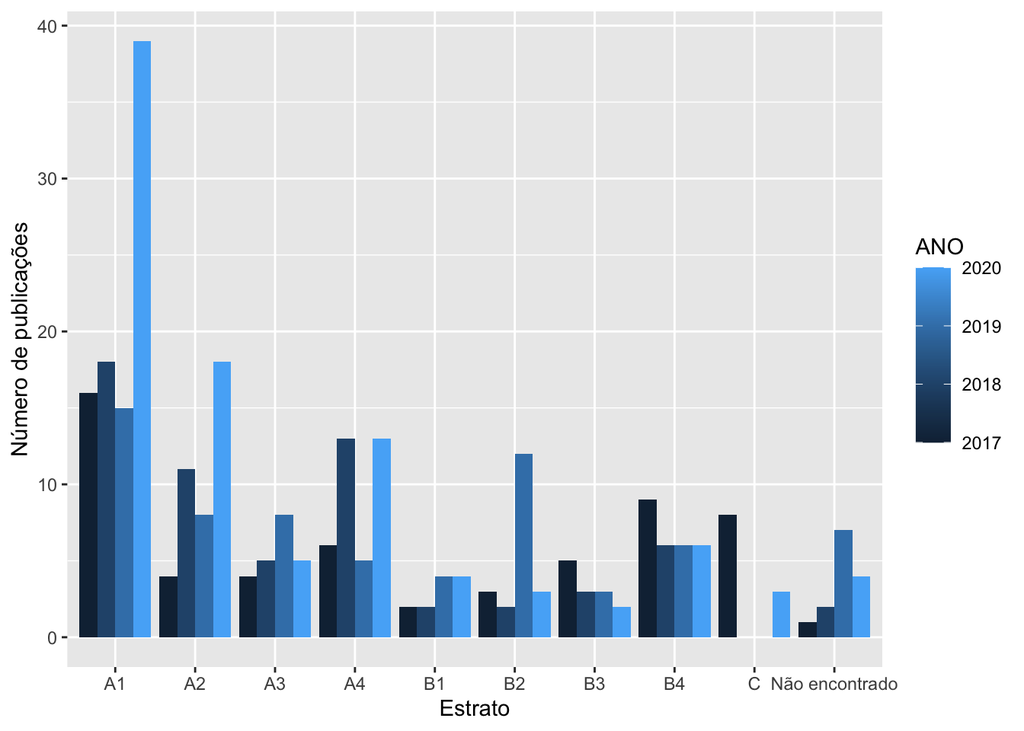

Figura1. Número de publicações por estrato qualis de Discentes e Egressos do PPG-ECOTAV no quadriênio 2017-2020.

```r
colnames(qualificado_keep) <- c(qualis_estrato, "Não encontrado")
qualificado_keep %>%
  as_tibble() %>%
  add_column(ANO = 2017:2020) %>%
  pivot_longer(!ANO) %>%
  ggplot(aes(x = name, y = value, group = ANO, fill = ANO)) +
  geom_col(position = "dodge") +
  xlab("Estrato") +
  ylab("Número de publicações")
```

## Porcentagem de discentes e egressos com A4-A1

A porcentagem de discentes e egressos com publicação A4+ foi calculada da seguinte maneira.

```r
NA1.A4 <- papers %>%
  group_by(NOME, ESTRATO) %>%
  summarise(n = n()) %>%
  filter(ESTRATO %in% qualis_estrato[1:4]) %>%
  pull(NOME) %>%
  unique() %>%
  length()
Ntotal <- length(lattes_nomes)
porcA1.A4 <- NA1.A4 / Ntotal
```

### Resultado

O resultado indicou que a porcentagem de discentes e egressos com publicação A4+ foi:

```r
porcA1.A4
```

```
## [1] 0.5039683
```